# Clean-Eating in Manhattan

#### (4) More VF restaurants than others: Clinton Neighborhood

Living in Manhattan is luck for clean-eating customers. Colorful ingredients, healthy cooking methods, and various recipes… Do these attract you? Does your moth keep watering now? Let’s go for a “green” bite, explore our neighborhoods and get the party started!

```python
df['zipcode'].value_counts().idxmax()
```

```
10019
```

```python
# 10019 Chelsea and Clinton, around Columbus Circles
```

```python
Clinton = df.loc[df['zipcode'] == 10019]
Clinton.head()
```

|  | Unnamed: 0 | name | latitude | longitude | zipcode | price | rating | review_count | Price_num |
| --- | --- | --- | --- | --- | --- | --- | --- | --- | --- |
| 8 | 8 | Beyond Sushi | 40.763310 | -73.977170 | 10019 | $$ | 4.5 | 675 | 2.0 |
| 10 | 10 | MTHR Vegan | 40.762410 | -73.988060 | 10019 | $$ | 4.5 | 230 | 2.0 |
| 22 | 22 | Westville Hell's Kitchen | 40.765770 | -73.987500 | 10019 | $$ | 4.5 | 118 | 2.0 |
| 27 | 27 | wagamama - midtown | 40.762900 | -73.978157 | 10019 | $$ | 4.5 | 30 | 2.0 |
| 39 | 39 | Bengal Tiger Indian Food | 40.763167 | -73.977131 | 10019 | $$ | 4.5 | 1891 | 2.0 |

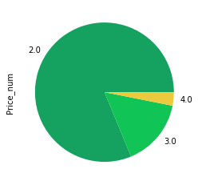

```python
colors = ['#15a15f', '#10c455', '#ebcb3d', '#f7f37c']
Count_price1 = Clinton['Price_num'].value_counts().sort_index().plot(kind='pie', colors=colors)
plt.show()
```

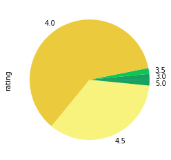

```python
colors = ['#15a15f', '#10c455', '#ebcb3d', '#f7f37c']
Count_rating1 = Clinton['rating'].value_counts().sort_index().plot(kind='pie', colors=colors)
plt.show()
```

```python
East_Village = df.loc[df['zipcode'] == 10003]
East_Village.head()
```

|  | Unnamed: 0 | name | latitude | longitude | zipcode | price | rating | review_count | Price_num |
| --- | --- | --- | --- | --- | --- | --- | --- | --- | --- |
| 1 | 1 | Spicy Moon East Village | 40.726740 | -73.987220 | 10003 | $$ | 4.5 | 291 | 2.0 |
| 18 | 18 | Bali Kitchen | 40.725371 | -73.987617 | 10003 | $$ | 4.5 | 137 | 2.0 |
| 21 | 21 | Divya's Kitchen | 40.723780 | -73.988490 | 10003 | $$ | 4.5 | 366 | 2.0 |
| 42 | 42 | LoveMama | 40.730386 | -73.986061 | 10003 | $$ | 4.5 | 4967 | 2.0 |
| 44 | 44 | Bar Verde | 40.726085 | -73.989736 | 10003 | $$ | 4.5 | 238 | 2.0 |

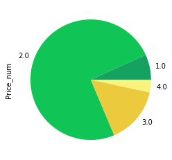

```python
colors = ['#15a15f', '#10c455', '#ebcb3d', '#f7f37c']
Count_price2 = East_Village['Price_num'].value_counts().sort_index().plot(kind='pie', colors=colors)
plt.show()
```

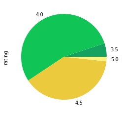

```python
colors = ['#15a15f', '#10c455', '#ebcb3d', '#f7f37c']
Count_rating2 = East_Village['rating'].value_counts().sort_index().plot(kind='pie', colors=colors)
plt.show()
```

Reference: [1] Why people in rich countries are eating more vegan food. (n.d.). Retrieved from https://www.economist.com/briefing/2018/10/13/why-people-in-rich-countries-are-eating-more-vegan-food. [2] Corsetti, S. (n.d.). The vegan movement is elitist. Retrieved from https://dailycollegian.com/2018/02/the-vegan-movement-is-elitist/. [3] Dean, M. (2014). You Are How You Eat? Femininity, Normalization, and Veganism as an Ethical Practice of Freedom. Societies, 4(2), 127–147. doi: 10.3390/soc4020127 [4] Sun, Y., & Paule, J. D. G. (2017). Spatial analysis of users-generated ratings of yelp venues. Open Geospatial Data, Software and Standards, 2(1). doi: 10.1186/s40965–017–0020–9 [5] Glaeser, E. L., Kim, H., & Luca, M. (2018). Nowcasting Gentrification: Using Yelp Data to Quantify Neighborhood Change. SSRN Electronic Journal. doi: 10.2139/ssrn.3123733 [6] Dean, M. (2014). You Are How You Eat? Femininity, Normalization, and Veganism as an Ethical Practice of Freedom. Societies, 4(2), 127–147. doi: 10.3390/soc4020127 [7] Glaeser, E. L., Kim, H., & Luca, M. (2017). Nowcasting the Local Economy: Using Yelp Data to Measure Economic Activity at Scale. SSRN Electronic Journal. doi: 10.2139/ssrn.3037603 [8] Oberst, L., & Oberst, L. (2018, January 18). Why the Global Rise in Vegan and Plant-Based Eating Isn't A Fad (600% Increase in U.S. Vegans Other Astounding Stats). Retrieved from https://foodrevolution.org/blog/vegan-statistics-global/.

```python
! jupyter nbconvert --to html Yelp API_clean-eating in Manhattan.ipynb
```

```
[NbConvertApp] WARNING | pattern 'API_clean-eating' matched no files
[NbConvertApp] WARNING | pattern 'in' matched no files
[NbConvertApp] WARNING | pattern 'Manhattan.ipynb' matched no files
[NbConvertApp] Converting notebook Yelp.ipynb to html
[NbConvertApp] Writing 2626820 bytes to Yelp.html
```